# Batch Correction

Lauren Rylaarsdam

2024-11-11

Single-cell analysis often involves integrating data from multiple contexts. Sometimes, artifacts can be introduced that reflect technical biases instead of true biological differences. While the binary nature of methylation makes it less susceptible to batch variability compared to RNA or ATAC-seq data, it is still important to assess if your dimensionality reduction is reflecting what is known of the biology.

We will give an example for how to batch integrate using the brain vignette data.

## Loading libraries and example data

If you haven’t already, load necessary libraries.

```r
library(amethyst)
library(data.table)
library(ggplot2)
library(ggrepel)
library(dplyr)
library(tibble)
library(tidyr)
library(plyr)
library(cowplot)
library(harmony)
```

Next, download the example brain vignette data (this only needs to be done once; ignore if you went through the vignette).

```r
download.file("https://adeylabopen.s3.us-west-2.amazonaws.com/amethyst/brain_vignette_workspace.RData", "~/Downloads/brain_vignette_workspace.RData", method = "curl")
download.file("https://raw.githubusercontent.com/lrylaarsdam/amethyst/main/vignettes/brain_vignette/brain_vignette_cellInfo.txt", "~/Downloads/brain_vignette_cellInfo.txt")
download.file("https://raw.githubusercontent.com/lrylaarsdam/amethyst/main/vignettes/brain_vignette/brain_vignette.annot", "~/Downloads/brain_vignette.annot", method = "curl")
```

Build the object according to steps in the brain vignette to obtain cell type annotations. If you have already followed the brain vignette, this step can be skipped if the data is still in your work space.

```r
load("~/Downloads/brain_vignette_workspace.RData")
obj <- addCellInfo(obj, file = "~/Downloads/brain_vignette_cellInfo.txt")
obj <- addAnnot(obj, file = "~/Downloads/brain_vignette.annot", name = "method")
obj@h5paths <- data.frame(row.names = rownames(obj@metadata),
                          paths = rep("~/Downloads/brain_vignette.h5", length(rownames(obj@metadata))))
obj@metadata <- obj@metadata |> dplyr::filter(cov > 1000000 & mch_pct < 12)
set.seed(111)
obj@reductions[["irlba"]] <- runIrlba(obj, genomeMatrices = c("ch_100k_pct", "cg_100k_score"), dims = c(5, 5), replaceNA = c("mch_pct", 0))
set.seed(111)
obj@reductions[["irlba_regressed"]] <- regressCovBias(obj, reduction = "irlba")
set.seed(111)
obj <- runCluster(obj, k_phenograph = 10, reduction = "irlba_regressed") # consider increasing k_phenograph to 50 for larger datasets
```

```
##   Finding nearest neighbors...DONE ~ 0 s
##   Compute jaccard coefficient between nearest-neighbor sets...DONE ~ 0.001 s
##   Build undirected graph from the weighted links...DONE ~ 0.006 s
##   Run louvain clustering on the graph ...DONE ~ 0.001 s
##   Return a community class
##   -Modularity value: 0.6575309
##   -Number of clusters: 5
```

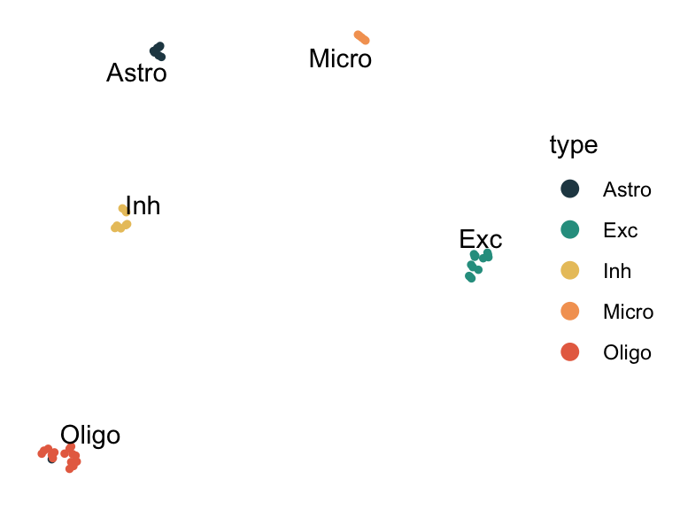

```r
set.seed(111)
obj <- runUmap(obj, neighbors = 5, dist = 0.01, method = "euclidean", reduction = "irlba_regressed")
obj@metadata[["type"]] <- dplyr::recode(obj@metadata[["cluster_id"]],
                                        "1" = "Astro",
                                        "2" = "Exc",
                                        "3" = "Micro",
                                        "4" = "Oligo",
                                        "5" = "Inh")

# define colors
pal <- makePalette(option = 13, n = 5)

# plot results
dimFeature(obj, colorBy = type, colors = pal, pointSize = 1) +
  geom_text_repel(aes(label = type), color = "black", data = obj@metadata |>
                    dplyr::group_by(type) |>
                    dplyr::summarise(umap_x = median(umap_x), umap_y = median(umap_y)))
```

## Simulate a batch effect

Now that we know the cell type identities, generate a simulated “batch” variable with roughly equal cell type composition.

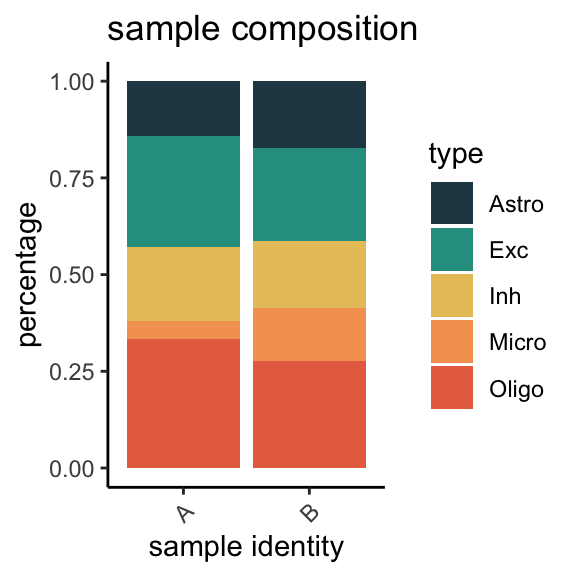

```r
set.seed(100)
obj@metadata <- obj@metadata |> tibble::rownames_to_column(var = "cell_id") |>
  dplyr::group_by(type) |>
  dplyr::mutate(batch = as.character(sample(c("A", "B"), n(), replace = T))) |>
  tibble::column_to_rownames(var = "cell_id")
sampleComp(obj, groupBy = "batch", colorBy = "type", colors = pal)
```

For this example, batch “B” will have sparser coverage than batch “A”. Remove values from a subset of windows in batch “B” using the commands below.

```r
set.seed(100)
windows <- order(sample(1:nrow(obj@genomeMatrices[["ch_100k_pct"]]), size = 1000, replace = F))
cells <- rownames(obj@metadata |> dplyr::filter(batch == "B"))

obj@genomeMatrices[["ch_100k_pct_batch"]] <- obj@genomeMatrices[["ch_100k_pct"]]
obj@genomeMatrices[["ch_100k_pct_batch"]][windows, cells] <- NA
```

We will just use the CH matrix from here on for simplicity, so re-run dimensionality reduction with and without the batch effect. Notice the shift introduced by the sparsity in batch “B”.

```r
# dimensionality reduction without batch effect
set.seed(111)
obj@reductions[["irlba"]] <- runIrlba(obj, genomeMatrices = c("ch_100k_pct"), dims = c(5), replaceNA = c(0))
obj <- runCluster(obj, k_phenograph = 10, reduction = "irlba_regressed") # consider increasing k_phenograph to 50 for larger datasets
```

```
##   Finding nearest neighbors...DONE ~ 0 s
##   Compute jaccard coefficient between nearest-neighbor sets...DONE ~ 0.001 s
##   Build undirected graph from the weighted links...DONE ~ 0.002 s
##   Run louvain clustering on the graph ...DONE ~ 0.001 s
##   Return a community class
##   -Modularity value: 0.6575309
##   -Number of clusters: 5
```

```r
obj <- runUmap(obj, neighbors = 5, dist = 0.01, method = "euclidean", reduction = "irlba_regressed")

# plot results
p1 <- dimFeature(obj, colorBy = batch, colors = c("#264653", "#E76F51"), pointSize = 1) + ggtitle("No batch effect")
p2 <- sampleComp(obj, groupBy = "batch", colorBy = "cluster_id", colors = pal) + ggtitle("")

# dimensionality reduction with batch effect
set.seed(111)
obj@reductions[["irlba_batch"]] <- runIrlba(obj, genomeMatrices = c("ch_100k_pct_batch"), dims = c(5), replaceNA = c(0))
obj <- runCluster(obj, k_phenograph = 10, reduction = "irlba_batch") # consider increasing k_phenograph to 50 for larger datasets
```

```
##   Finding nearest neighbors...DONE ~ 0 s
##   Compute jaccard coefficient between nearest-neighbor sets...DONE ~ 0.001 s
##   Build undirected graph from the weighted links...DONE ~ 0.002 s
##   Run louvain clustering on the graph ...DONE ~ 0 s
##   Return a community class
##   -Modularity value: 0.5449189
##   -Number of clusters: 5
```

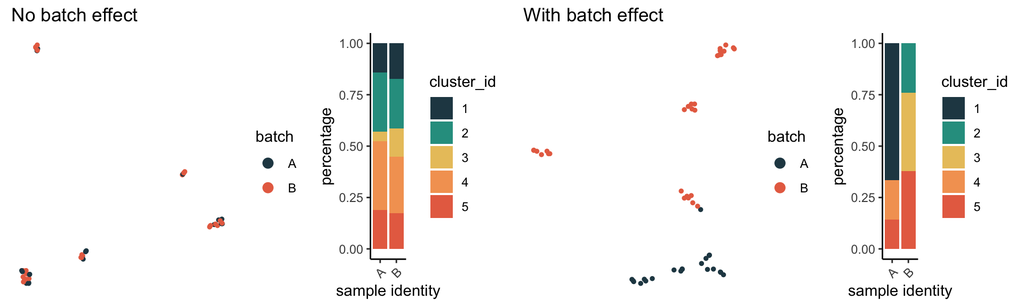

```r
obj <- runUmap(obj, neighbors = 5, dist = 0.01, method = "euclidean", reduction = "irlba_batch")

# plot results
p3 <- dimFeature(obj, colorBy = batch, colors = c("#264653", "#E76F51"), pointSize = 1) + ggtitle("With batch effect")
p4 <- sampleComp(obj, groupBy = "batch", colorBy = "cluster_id", colors = pal) + ggtitle("")
plot_grid(p1, p2, p3, p4, nrow = 1, rel_widths = c(2.5, 1.6, 2.5, 1.6))
```

We will explore three ways to ameliorate this simulated batch effect.

## Method 1: Integration with Harmony

The first method we use for batch correction is Harmony, a robust package for integration of single-cell data developed by Korsunsky et al. doi:10.1038/s41592-019-0619-0 Harmony is quite simple to implement by passing the parameter to be reconciled in the metadata to the irlba matrix. See ?RunHarmony.default for a thorough explanation of available parameters.

```r
set.seed(111)
obj@reductions[["irlba_harmony"]] <- RunHarmony(obj@reductions[["irlba_batch"]], obj@metadata, c("batch"), sigma = 1)
obj <- runCluster(obj, k_phenograph = 10, reduction = "irlba_harmony") # consider increasing k_phenograph to 50 for larger datasets
```

```
##   Finding nearest neighbors...DONE ~ 0 s
##   Compute jaccard coefficient between nearest-neighbor sets...DONE ~ 0.001 s
##   Build undirected graph from the weighted links...DONE ~ 0.002 s
##   Run louvain clustering on the graph ...DONE ~ 0.001 s
##   Return a community class
##   -Modularity value: 0.5018047
##   -Number of clusters: 4
```

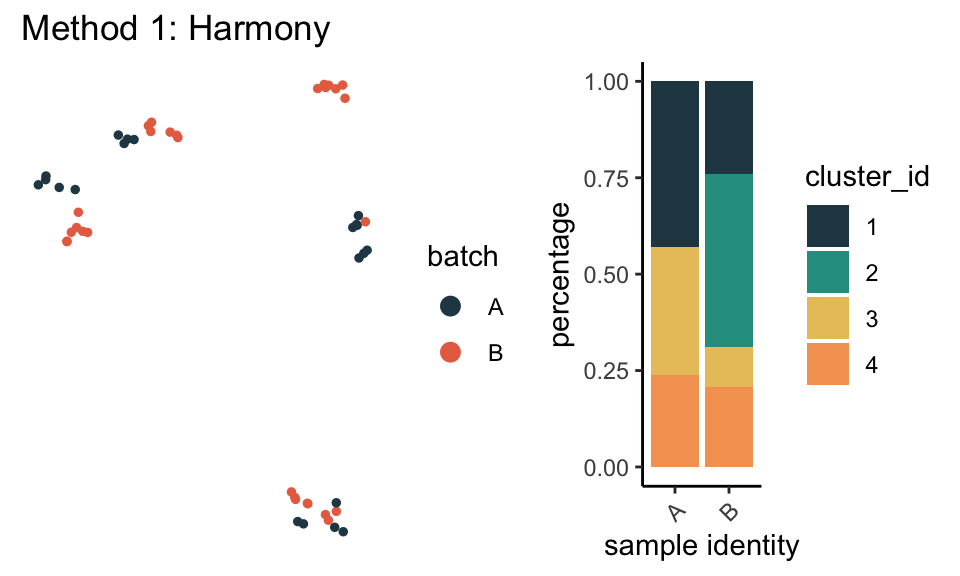

```r
obj <- runUmap(obj, neighbors = 5, dist = 0.01, method = "euclidean", reduction = "irlba_harmony")

# plot results
p5 <- dimFeature(obj, colorBy = batch, colors = c("#264653", "#E76F51"), pointSize = 1) + ggtitle("Method 1: Harmony")
p6 <- sampleComp(obj, groupBy = "batch", colorBy = "cluster_id", colors = pal) + ggtitle("")
plot_grid(p5, p6, rel_widths = c(2.5, 2))
```

Since we are using the mCH matrix only, this worked better for integrating neurons versus glia, but hopefully the illustration is clear. A larger dataset should improve results as well.

## Method 2: Subset biologically relevant highly variable features

If batch effects are clearly driving your clustering, it can sometimes be useful to enrich for features containing relevant biological variability. While, this does require some prior knowledge of your system, often metadata parameters can be used (like age or tissue origin). In this context, we will select for genomic windows with high %mCH standard deviation across cell types.

```r
# determine genomic windows with high standard deviation in mean %mCH between cell types
ch_window_values <- merge(obj@metadata |> dplyr::select(type),
                          t(obj@genomeMatrices[["ch_100k_pct_batch"]]), by = 0) |>
  dplyr::rename("cell_id" = "Row.names") |>
  tidyr::pivot_longer(-c("cell_id", "type"), names_to = "window", values_to = "m") |>
  dplyr::filter(m != 0)
ch_window_sd <- ch_window_values |> dplyr::group_by(window, type) |>
  dplyr::filter(n() > 5) |> # make sure there are enough values to obtain a reasonable mean
  dplyr::summarise(type_mean = mean(m, na.rm = TRUE)) |> # calculate the mean %mCH for each window across each subtype
  dplyr::group_by(window) |> dplyr::filter(n() > 3) |> # make sure most cell types are represented
  dplyr::mutate(type_sd = sd(type_mean, na.rm = TRUE))

top_ch_window_sd <- ch_window_sd |>
  dplyr::distinct(window, type_sd) |>
  dplyr::ungroup() |>
  slice_max(order_by = type_sd, n = 5000) |>
  dplyr::pull(window)

# subset the original matrix to the windows with high SD
obj@genomeMatrices[["ch_100k_pct_batch_highSD"]] <- obj@genomeMatrices[["ch_100k_pct_batch"]][top_ch_window_sd, ]

# perform dimensionality reduction
obj@reductions[["irlba_highSD"]] <- runIrlba(obj, genomeMatrices = c("ch_100k_pct_batch_highSD"), dims = c(5), replaceNA = c(0))
set.seed(111)
obj <- runCluster(obj, k_phenograph = 10, reduction = "irlba_highSD") # consider increasing k_phenograph to 50 for larger datasets
```

```
##   Finding nearest neighbors...DONE ~ 0.001 s
##   Compute jaccard coefficient between nearest-neighbor sets...DONE ~ 0.001 s
##   Build undirected graph from the weighted links...DONE ~ 0.002 s
##   Run louvain clustering on the graph ...DONE ~ 0.001 s
##   Return a community class
##   -Modularity value: 0.5747758
##   -Number of clusters: 5
```

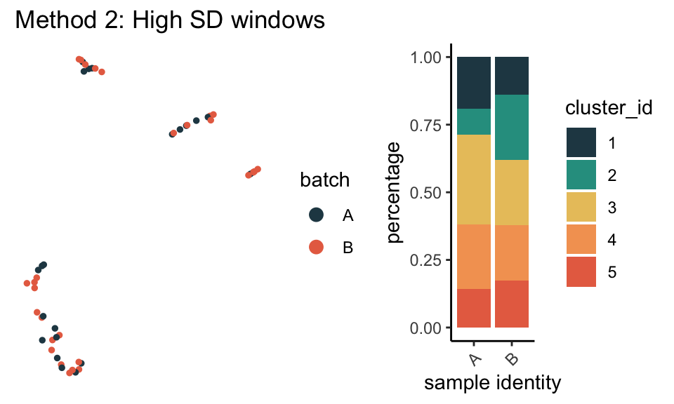

```r
set.seed(111)
obj <- runUmap(obj, neighbors = 5, dist = 0.01, method = "euclidean", reduction = "irlba_highSD")

# plot results
p7 <- dimFeature(obj, colorBy = batch, colors = c("#264653", "#E76F51"), pointSize = 1) + ggtitle("Method 2: High SD windows")
p8 <- sampleComp(obj, groupBy = "batch", colorBy = "cluster_id", colors = pal) + ggtitle("")
plot_grid(p7, p8, rel_widths = c(2.5, 2))
```

## Method 3: Perform dimensionality reduction on windows containing values in most cells

Since methylation data is typically binary in nature, we often see batch effects related to sparsity or coverage. In this context, we can alleviate the sparsity bias by only performing dimensionality reduction on windows containing values for the majority of cells.

```r
# sometimes removing Y chromosome windows can remove major sources of sample variability
obj@genomeMatrices[["ch_100k_pct_batch_highN"]] <- obj@genomeMatrices[["ch_100k_pct_batch"]][!grepl("chrY", rownames(obj@genomeMatrices[["ch_100k_pct_batch"]])), ]
# remove windows with values in < 80% of the cells
obj@genomeMatrices[["ch_100k_pct_batch_highN"]] <- obj@genomeMatrices[["ch_100k_pct_batch_highN"]][rowSums(!is.na(obj@genomeMatrices[["ch_100k_pct_batch_highN"]])) >= nrow(obj@metadata)*.80, ]

# double-check you didn't lose all your windows during subsetting. If you have small windows, you will probably need a lower threshold.
nrow(obj@genomeMatrices[["ch_100k_pct_batch_highN"]])
```

```
## [1] 28039
```

```r
# run dimensionality reduction
set.seed(111)
obj@reductions[["irlba_highN"]] <- runIrlba(obj, genomeMatrices = c("ch_100k_pct_batch_highN"), dims = c(5), replaceNA = c(0))
obj <- runCluster(obj, k_phenograph = 10, reduction = "irlba_highN") # consider increasing k_phenograph to 50 for larger datasets
```

```
## Run Rphenograph starts:
##   -Input data of 50 rows and 5 columns
##   -k is set to 10
```

```
##   Finding nearest neighbors...DONE ~ 0 s
##   Compute jaccard coefficient between nearest-neighbor sets...DONE ~ 0.002 s
##   Build undirected graph from the weighted links...DONE ~ 0.002 s
##   Run louvain clustering on the graph ...DONE ~ 0.001 s
```

```
## Run Rphenograph DONE, totally takes 0.004999999999999s.
```

```
##   Return a community class
##   -Modularity value: 0.6094059
##   -Number of clusters: 5
```

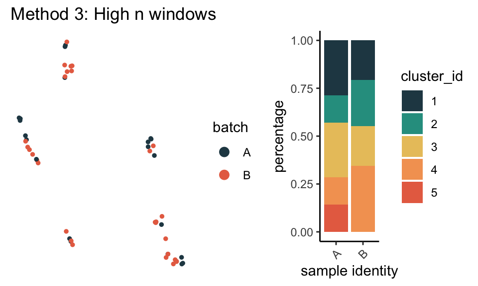

```r
obj <- runUmap(obj, neighbors = 5, dist = 0.01, method = "euclidean", reduction = "irlba_highN")

# plot results
p9 <- dimFeature(obj, colorBy = batch, colors = c("#264653", "#E76F51"), pointSize = 1) + ggtitle("Method 3: High n windows")
p10 <- sampleComp(obj, groupBy = "batch", colorBy = "cluster_id", colors = pal) + ggtitle("")
plot_grid(p9, p10, rel_widths = c(2.5, 2))
```

## Troubleshooting

If none of these methods removes suspected sources of technical bias, it can also be very informative to manually investigate sources of variability in the matrix you are using for dimensionality reduction. In the example below, I am plotting values in batch A versus batch B with point size reflective of the number of observations.

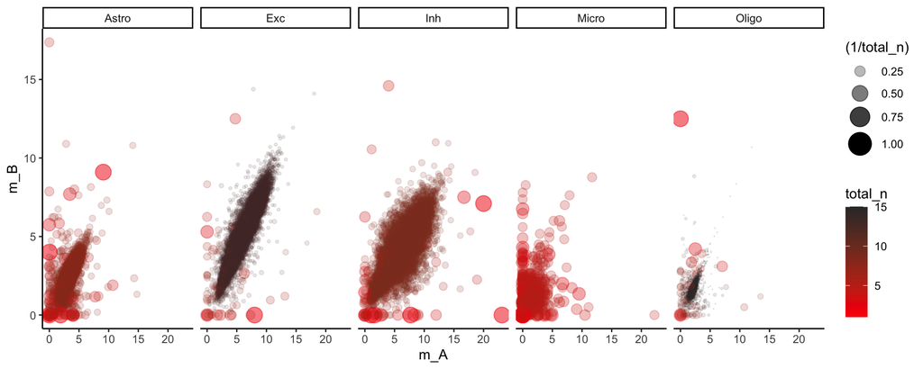

```r
# convert matrix to ggplot-conducive format
ch_window_values <- merge(obj@metadata |> dplyr::select(type, batch), t(obj@genomeMatrices[["ch_100k_pct_batch"]]), by = 0) |>
  dplyr::rename("cell_id" = "Row.names") |>
  tidyr::pivot_longer(-c("cell_id", "type", "batch"), names_to = "window", values_to = "m") |>
  dplyr::filter(!is.na(m)) |>
  dplyr::group_by(window, type, batch) |>
  dplyr::summarise(m = mean(m, na.rm = TRUE), n = n()) |>
  tidyr::pivot_wider(names_from = batch, values_from = c(m, n)) |>
  dplyr::mutate(total_n = sum(n_A, n_B, na.rm = T))
# plot window values in A vs B. facet by cell type. larger dots have fewer values.
ggplot(ch_window_values, aes(x = m_A, y = m_B, color = total_n, size = (1/total_n), alpha = (1/total_n))) +
  geom_point() +  theme_classic() +
  scale_size_continuous(range = c(0.01, 8)) +
  facet_wrap(vars(type), nrow = 1) +
  scale_color_gradientn(colors = c("red", "grey20"))
```

You will notice that in general, discordant values have a low number of observations. Also, over 5k observations dropped out of the plot. This suggests stricter thresholds for window inclusion may alleviate batch effects. We saw this to be the case in the above examples.

Hopefully this vignette helps you get on the right track for removal of technical artifacts in your single-cell methylation data. Please reach out if you have any questions.